# Note-Feature engineering for structure data

Weiquan Luo

2021-08-01

```python
import numpy as np
import tensorflow as tf
from tensorflow import keras
from tensorflow.keras import layers
print("Version: TensorFlow", tf.__version__)
```

```
Version: TensorFlow 2.5.0
```

# Feature engineering for structure data

`tf.feature_column` is the bridge to map from columns in a CSV to features used to train tensorflow model.

## Feature engineering workflow

- Step 1. input data from .csv file
- Step 2. feature engineering base on type, such as numeric and categorical
- Step 3. feed Dense Tensor into model (tensorflow model only take Dense Tensor as input)

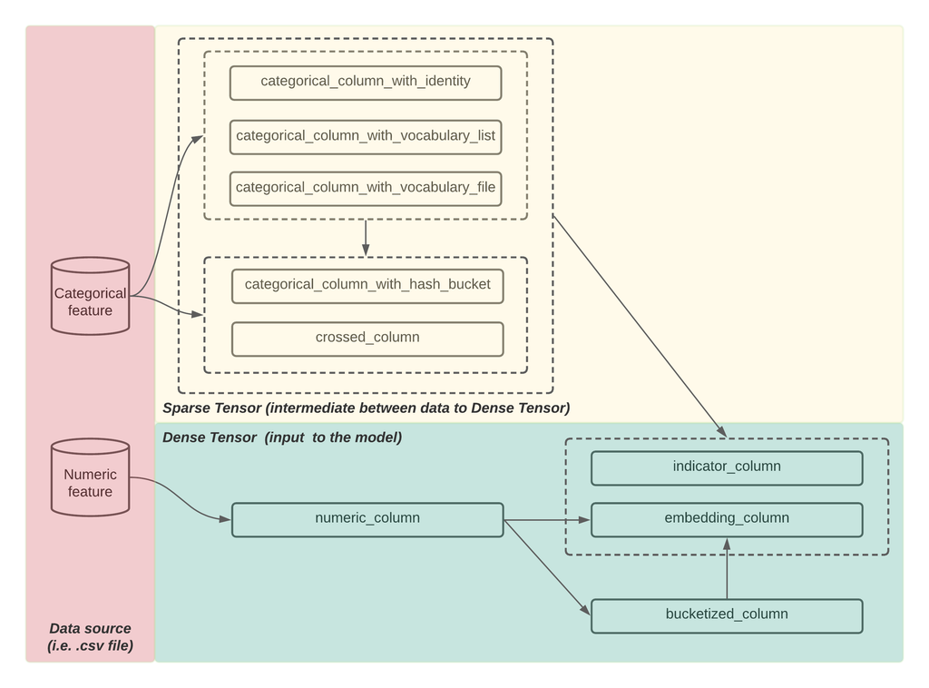

## Description

[output not shown]

## Example code

```python
# A utility method to create a feature column, and to transform a batch of data
def demo(feature_column):
    # reference: https://www.tensorflow.org/tutorials/structured_data/feature_columns?hl=zh-cn
    feature_layer = layers.DenseFeatures(feature_column)
    print(feature_layer(example_batch))

# example batch of data
example_batch =  {
    'var_numeric': np.arange(1,7),
    'var_categorical': np.tile(['A','B','C'], 2),
}
example_batch
```

```
{'var_numeric': array([1, 2, 3, 4, 5, 6]),
 'var_categorical': array(['A', 'B', 'C', 'A', 'B', 'C'], dtype='<U1')}
```

### dense feature

The feature columns used as inputs to the model should be instances of classes derived from _DenseColumn such as:

- numeric_column,
- bucketized_column,
- indicator_column,
- embedding_column

```python
print("numeric_column:")
layer = tf.feature_column.numeric_column("var_numeric", default_value=None)
demo(layer)

print("bucketized_column:")
boundaries = [2,4]
layer = tf.feature_column.numeric_column('var_numeric', default_value=None)
layer = tf.feature_column.bucketized_column(layer, boundaries=boundaries)
demo(layer)
```

```
numeric_column:
tf.Tensor(
[[1.]
 [2.]
 [3.]
 [4.]
 [5.]
 [6.]], shape=(6, 1), dtype=float32)
bucketized_column:
tf.Tensor(
[[1. 0. 0.]
 [0. 1. 0.]
 [0. 1. 0.]
 [0. 0. 1.]
 [0. 0. 1.]
 [0. 0. 1.]], shape=(6, 3), dtype=float32)
```

### categorical feature

```python
print("categorical_column_with_identity:")
layer = tf.feature_column.categorical_column_with_identity("var_numeric", num_buckets=4, default_value=None)
layer = tf.feature_column.indicator_column(layer)
demo(layer)

print("categorical_column_with_vocabulary_list / categorical_column_with_vocabulary_file:")
layer = tf.feature_column.categorical_column_with_vocabulary_list('var_categorical', ['A', 'B', 'C'])
layer = tf.feature_column.indicator_column(layer)
demo(layer)

print("categorical_column_with_hash_bucket:")
layer = tf.feature_column.categorical_column_with_hash_bucket('var_categorical', hash_bucket_size=2, dtype=tf.string)
layer = tf.feature_column.indicator_column(layer)
demo(layer)

print("crossed_column:")
col_1 = tf.feature_column.categorical_column_with_vocabulary_list('var_categorical', ['A', 'B', 'C'], dtype=tf.string)
col_2 = tf.feature_column.categorical_column_with_identity('var_numeric', num_buckets=2, default_value=0)
layer = tf.feature_column.crossed_column([col_1,col_2], 16)
layer = tf.feature_column.indicator_column(layer)
demo(layer)
```

```
categorical_column_with_identity:
tf.Tensor(
[[0. 1. 0. 0.]
 [0. 0. 1. 0.]
 [0. 0. 0. 1.]
 [0. 0. 0. 0.]
 [0. 0. 0. 0.]
 [0. 0. 0. 0.]], shape=(6, 4), dtype=float32)
categorical_column_with_vocabulary_list / categorical_column_with_vocabulary_file:
tf.Tensor(
[[1. 0. 0.]
 [0. 1. 0.]
 [0. 0. 1.]
 [1. 0. 0.]
 [0. 1. 0.]
 [0. 0. 1.]], shape=(6, 3), dtype=float32)
categorical_column_with_hash_bucket:
tf.Tensor(
[[1. 0.]
 [1. 0.]
 [0. 1.]
 [1. 0.]
 [1. 0.]
 [0. 1.]], shape=(6, 2), dtype=float32)
crossed_column:
tf.Tensor(
[[0. 0. 0. 1. 0. 0. 0. 0. 0. 0. 0. 0. 0. 0. 0. 0.]
 [0. 1. 0. 0. 0. 0. 0. 0. 0. 0. 0. 0. 0. 0. 0. 0.]
 [0. 0. 0. 0. 0. 0. 0. 0. 0. 1. 0. 0. 0. 0. 0. 0.]
 [0. 0. 0. 0. 0. 0. 0. 0. 1. 0. 0. 0. 0. 0. 0. 0.]
 [0. 1. 0. 0. 0. 0. 0. 0. 0. 0. 0. 0. 0. 0. 0. 0.]
 [0. 0. 0. 0. 0. 0. 0. 0. 0. 1. 0. 0. 0. 0. 0. 0.]], shape=(6, 16), dtype=float32)
```

If you have categorical features, you need to wrap them with :

- indicator_column: most often used.
- embedding_column: use for dimentional reduction when feature have many different values

```python
print("indicator_column:")
layer = tf.feature_column.categorical_column_with_hash_bucket('var_categorical', hash_bucket_size=2, dtype=tf.string)
layer = tf.feature_column.indicator_column(layer)
demo(layer)

print("embedding_column:")
layer = tf.feature_column.categorical_column_with_vocabulary_list('var_categorical', ['A', 'B', 'C'], dtype=tf.string)
layer = tf.feature_column.embedding_column(layer, 2, combiner='sqrtn')
demo(layer)
```

```
indicator_column:
tf.Tensor(
[[1. 0.]
 [1. 0.]
 [0. 1.]
 [1. 0.]
 [1. 0.]
 [0. 1.]], shape=(6, 2), dtype=float32)
embedding_column:
tf.Tensor(
[[-0.29650226  0.40554228]
 [-0.59952354  0.82049197]
 [ 0.4452031   0.47114116]
 [-0.29650226  0.40554228]
 [-0.59952354  0.82049197]
 [ 0.4452031   0.47114116]], shape=(6, 2), dtype=float32)
```

# Workflow of deep learning on structured data with Tensorflow

*Step 1.*: load sample as tf dataset.  
*Step 2.* `tf.feature_column`: Map from columns in the CSV to features.  
*Step 3.* `tf.keras.layers.Input()`: define the entering point of denseTensor into model. Using pandas column name to identify input features of layers.  
*Step 4.* `tf.keras.layers.DenseFeatures()`: the entering point for converting feature_column to a denseTensor. pandas column that matching the identification in feature columns are converted to denseTensor.  
*Step 5.* `tf.keras.layers`: building computational graph by connecting layer with tensor.  
*Step 6.* `tf.keras.Model()`: groups layers into an object.  
*Step 7.* `model.compile()`: add loss, optimizer, metrics.  
*Step 8.* `model.fit()`: train model by gradient descent.

## Example code: Framework

*Step 1.*: load sample as tf dataset

```
def get_dataset(file_path):
    dataset = tf.data.experimental.make_csv_dataset(
        file_path,
        batch_size=12,
        label_name='label',
        na_value="0",
        num_epochs=1,
        ignore_errors=True)
    return dataset
training_samples_file_path = "dataset.csv"
train_dataset = get_dataset(training_samples_file_path)
```

*Step 2.* `tf.feature_column`: Map from columns in the CSV to features.

**This note will focus on this part, see the following section**

*Step 3.* `tf.keras.layers.Input()`: define the entering point of denseTensor into model. Using the pandas column name to identify the input feature of a layer

```
inputs = {
    'Item_Id': tf.keras.layers.Input(name='Item_Id', shape=(), dtype='int32'),
    'Category_Id': tf.keras.layers.Input(name='Category_Id', shape=(), dtype='int32'),
    'User_Id': tf.keras.layers.Input(name='User_Id', shape=(), dtype='int32'),
}
```

*Step 4.* `tf.keras.layers.DenseFeatures()`: the entering point for converting feature_column to a denseTensor.

```
- pandas column that matching the identification in feature columns are converted to denseTensor
```

*Step 5.* `tf.keras.layers`: building computational graph by connecting layer with tensor *Step 6.* `tf.keras.Model()`: groups layers into an object

```
def build_model():
    model = tf.keras.Model()
    return model
model = build_model(inputs, output)
```

*Step 7.* `model.compile()`: add loss, optimizer, metrics

```
model.compile(
    loss='binary_crossentropy',
    optimizer='adam',
    metrics=['accuracy', tf.keras.metrics.AUC(curve='ROC'), tf.keras.metrics.AUC(curve='PR')]
```

*Step 8.* `model.fit()`: train model by gradient descent

```
model.fit(train_dataset, epochs=2)
```